# CALIDAD DE CONEXIÓN

### Obvservaciones:

P4:

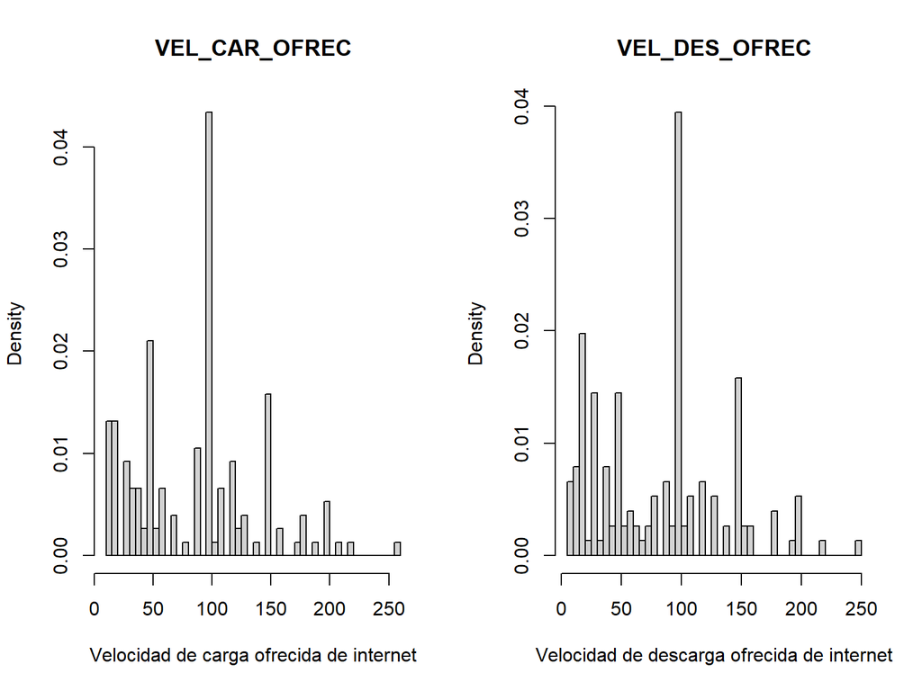

***

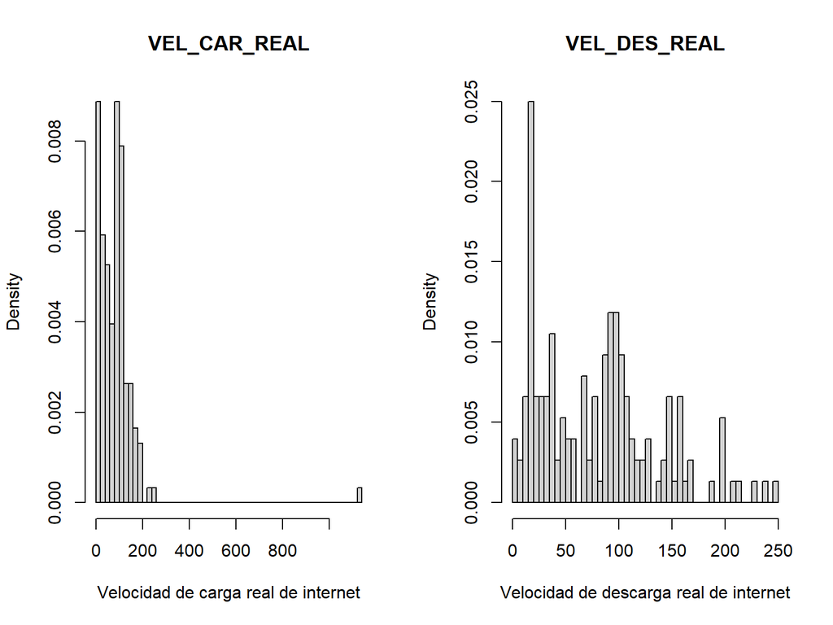

#### **Parámetros del Estudio**: {.smaller .build}

* **Nivel de confianza:** $95 \%$

* **Significancia:** $\alpha=0.05$

* **Tamaño de la muestra:** $152$

***

[output not shown]

***

#### **Intervalos de confianza Para la media**:

***

**Intervalo de confianza para la `media`**:

[output not shown]

***

**Precisión de confianza para la `media`**:

[output not shown]

***

[output not shown]

***

#### **Intervalos de confianza de las proporciones**:

***

**Intervalos de confianza de las proporciones`**:

[output not shown]

***

## 3. EXPLORATORIAS {.build}

- ¿Existe menor gasto de dinero en San Isidro comparado con el distrito de Surco?

`## Group.1 x ## 1 Barranco 3250 ## 2 San Borja 1229 ## 3 San isidro 2029 ## 4 SJ Miraflores 5490 ## 5 Surco 2090`

Como se puede observar, el dinero que se gasta en la adquisición del servicio de Internet es mayor en Surco (S/.2090) en comparación al distrito de San Isidro (S/. 2029) durante el periodo de estudio. Se puede deducir del resultado obtenido que por la cantidad de entrevistados es que este se obtiene, así como se muestra en la siguiente gráfica.

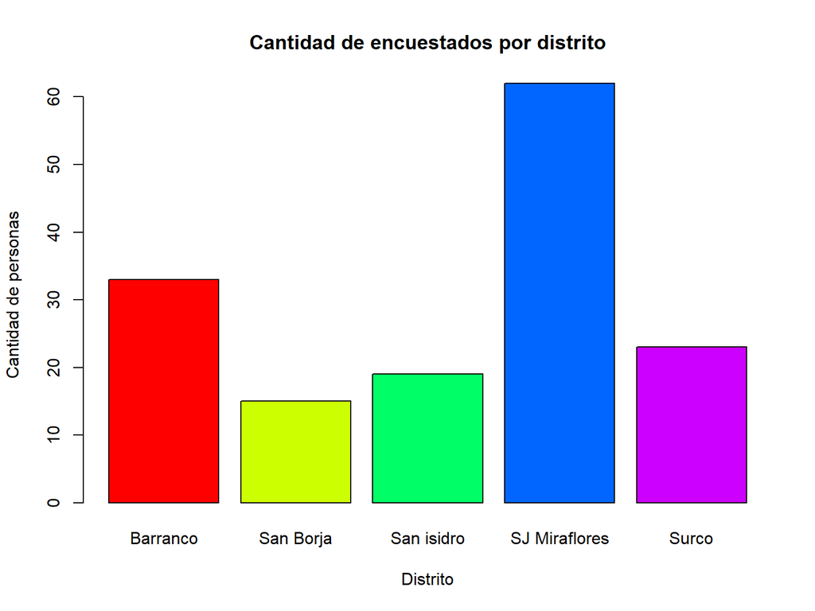

```r
DISTRITO<-table(CALIDCONEX$DISTRITO)
barplot(DISTRITO,main = "Cantidad de encuestados por distrito",xlab="Distrito", ylab = "Cantidad de personas", col = rainbow(5))
```

Además, de la gráfica podemos observar que a pesar de la baja cantidad de encuestados en el distrito de San Isidro, este se encuentra muy cerca al gasto total que tienen los entrevistados en Surco, por lo que decimos que el dinero gastado en Surco no es tan significativo que en San Isidro, es decir que las personas encuestadas en este distrito, gastan poco en el servicio de Internet.

# 4. ANÁLISIS INFERENCIAL

- ¿Ha disminuido la demanda del acceso a Internet en los distritos muestreados con respecto al total de personas?

En términos generales, la respuesta a esta pregunta sería “NO”. Como se pudo observar gráfica anterior “Cantidad de encuestados por distrito” y en esta gráfica:

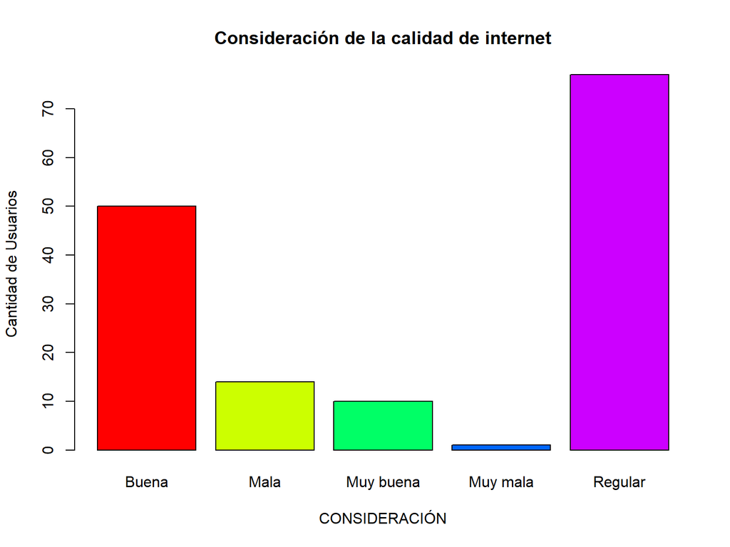

```r
APRE<-table(CALIDCONEX$CONSIDERACION)
barplot(APRE,main = "Consideración de la calidad de internet",xlab="CONSIDERACIÓN", ylab = "Cantidad de Usuarios", col = rainbow(5))
```

En ambas gráficas nos damos cuenta que los usuarios consideran que el Internet brindado por su operador es regular, por ende se podría decir que el consumo de Internet no se reduciría, sino más bien, el que si lo haría sería la variable “proveedor” ya que los usuarios que consideraron que su Internet es de mala a muy mala calidad tienen un disgusto, sin embargo, cabe destacar que esto ocurre al menos en nuestro periodo de estudio con nuestros datos específicos y estas tendencias podrían cambiar más adelante en el tiempo por diversos factores. Por lo tanto, este hallazgo sería válido solo para el periodo de tiempo que estamos estudiando y además nos puede servir para hacer algunas predicciones respecto a estas variables.

# 5. ANÁLISIS PREDICTIVO

- ¿Es posible predecir si en los próximos meses la demanda de Internet aumentará? No, esto debido a que el el uso de Internet no solo obedece a variables ya antes mencionadas, ya que para predecir su comportamiento es necesario evaluar también otras variables que no estamos considerando.